# Project 4: Exploratory Data Analysis

An Analysis of International Crisis Behavior

Matthew R. Versaggi, MS, MBA - Artificial Intelligence Engineer

June 23, 2016

[figure not shown]

# 1 Introduction

This is an structured exploration of the **The International Crisis Behavior (ICB) Project** dataset, which can be found here: http://sites.duke.edu/icbdata/data-collections/. The aim of the ICB Project is to shed light on a pervasive phenomenon of world politics, military conflict, and sovereign state crises.

- **Key Goals**: (1) Explore key crisis attributes, interactions and relationships by ERA: (WW2, Cold War, Super Power), (2) explore the behaviors of Major (those with the highest frequencies) crisis “Actors” by ERA, (3) explore the USA crises during the Cold War ERA, and finally (4) explore some interesting multidimensional crisis characteristics of the dataset in unique ways.
- The **prime objective** is to guide the reader through the exploration of the **four key goals** stated above, in a methodical, pragmatic fashion, in order to provide an appreciation for the richness (and gravity) of this dataset.
- A **secondary objective** is to provide a structured framework in which the data could speak for itself and tell its own story. Every effort will be made to adhear to the spirit of this objective.

# 2 Explorations of the Dataset Structure

This dataset consists of 470 unique crises, **95 attributes (variables), 1,036 crisis actors (records)**, including 35 protracted conflicts, all from the period of **1918 to 2013**.

- It is a rich dataset consisting almost entirely of **categorical** (no ordering) and **ordinal** (categorical but with ordering) data.

I have augmented the dataset with a half dozen transformed variables to better facilitate the conveying of the information in some of the various plots used in the explorations.

There are **only a dozen attributes** of the 95 available which will be the **focus** of this exploration. These are listed in the section “Exploration of Selected Crisis Attributes”.

**Below** is the structure of the dataset:

```
## 'data.frame':    1036 obs. of  95 variables:
##  $ icb2    : Factor w/ 2 levels "ICB2","UCB2": 1 1 1 1 1 1 1 1 1 1 ...
##  $ crisno  : int  1 2 2 3 4 4 4 4 5 5 ...
##  $ cracno  : int  1 2 3 4 5 6 7 8 9 10 ...
##  $ cracid  : int  365 93 94 365 365 366 368 367 315 290 ...
##  $ actor   : Factor w/ 143 levels "AFG","ALB","ALG",..: 109 91 29 109 109 42 77 73 33 103 ...
##  $ systrgyr: int  1918 1918 1918 1918 1918 1918 1918 1918 1919 1919 ...
##  $ systrgmo: int  5 5 5 6 11 11 11 11 1 1 ...
##  $ systrgda: int  NA 25 25 23 18 18 18 18 15 15 ...
##  $ crisname: Factor w/ 469 levels "AALAND ISLANDS",..: 377 113 113 378 27 27 27 27 431 431 ...
##  $ triggr  : int  9 7 4 7 6 9 9 9 2 7 ...
##  $ yrtrig  : int  1918 1918 1919 1918 1918 1918 1918 1918 1919 1919 ...
##  $ motrig  : int  5 5 1 6 11 11 12 12 1 1 ...
##  $ datrig  : int  NA 25 25 23 18 22 NA NA 15 23 ...
##  $ trigent : int  996 94 996 997 366 365 365 365 290 315 ...
```

[output cut: 81 more lines]

```
##   icb2 crisno cracno cracid actor systrgyr systrgmo systrgda
## 1 ICB2      1      1    365   RUS     1918        5       NA
## 2 ICB2      2      2     93   NIC     1918        5       25
## 3 ICB2      2      3     94   COS     1918        5       25
## 4 ICB2      3      4    365   RUS     1918        6       23
## 5 ICB2      4      5    365   RUS     1918       11       18
## 6 ICB2      4      6    366   EST     1918       11       18
##               crisname triggr yrtrig motrig datrig trigent trigloc southv
## 1  RUSSIAN CIVIL WAR I      9   1918      5     NA     996       2    220
## 2     COSTA RICAN COUP      7   1918      5     25      94       1     94
## 3     COSTA RICAN COUP      4   1919      1     25     996       2     93
## 4 RUSSIAN CIVIL WAR II      7   1918      6     23     997       1    200
## 5  BALTIC INDEPENDENCE      6   1918     11     18     366       1    366
## 6  BALTIC INDEPENDENCE      9   1918     11     22     365       1    365
##   southpow sizedu strcdu comlev majres yerres monres dayres trgresra
```

[output cut: 55 more lines]

# 3 Validate Datset with external Sources

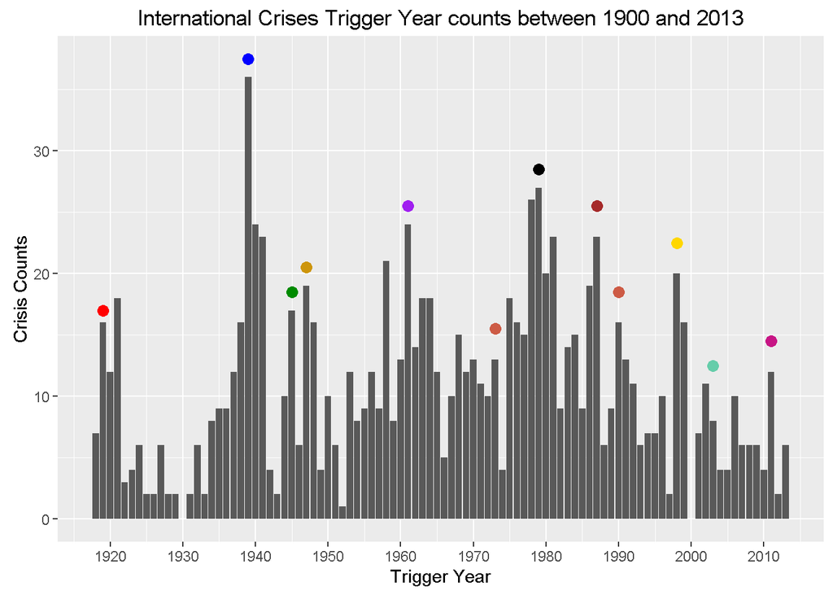

**Rationale:**

Part of the process of any exploratory data analysis is to perform a preliminary “gut check” of the data with an external source just to verify that it “makes sense”, if even only in a cursory fashion. This section is that vetting process.

- **NOTE:** The colored dots on the bar chart correspond to the heightened key international crisis levels during the time period of 1918 - 2013. They **also** correspond to the key international crises below (left to right on the chart is top to bottom of the list). This is a reasonable “gut check” that the data is indeed not bad data. The table below was constructed via commonly found historical records of the time period.
- 1919. - Russian Civil War
- 1939. - World War 2 starts
- 1945. - Cold War Starts
- 1947. - The 1947 Arab-Israeli war
- 1961. - Berlin Crisis
- 1973. - The 1973 Arab-Israeli War
- 1979. - Soviet-Afghan War
- 1987. - 1987 Sino-Indian skirmish
- 1990. - Gulf War
- 1998. - Kosovo War
- 2003. - Iraq War
- 2011. - Syrian Civil War

# 4 Exploration of Selected Crisis Attributes

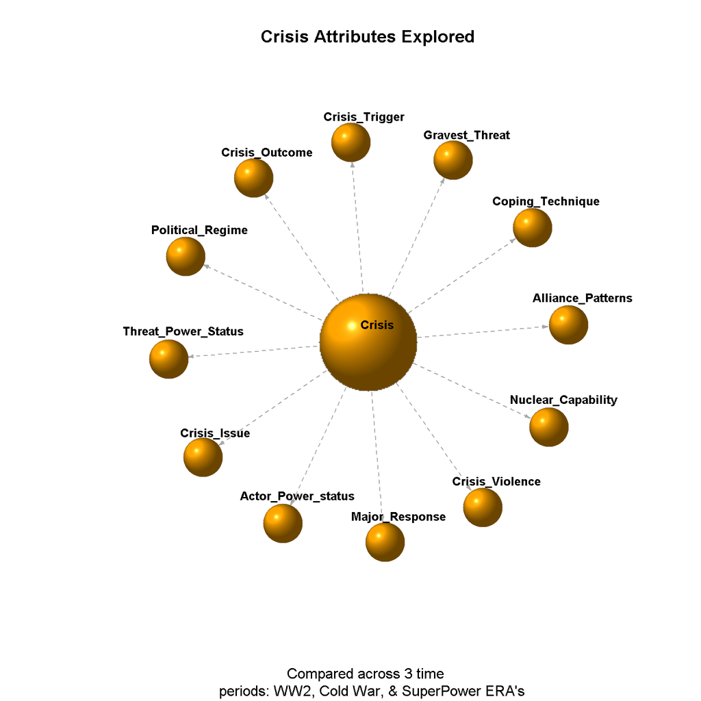

## 4.1 Attributes List used in this exploration:

1. “Crisis Trigger”
2. “Crisis Issue”
3. “Major Response”
4. “Coping Technique”
5. “Actor Power Status
6. “Threat Power Status”
7. “Crisis Violence”
8. “Political Regime”
9. “Alliance Patterns
10. “Nuclear Capability”
11. “Gravest Threat”
12. “Crisis Outcome”

## 4.2 Definitions of Attributes:

- **NOTE**: It is prudent to remind the reader to peruse this section **carefully** as the precise definitions of these attributes and their values takes on special meanings in some cases, and will aide in understanding some of the explanatory graphs later on.

> **“Crisis Trigger”**
- The trigger or precipitating cause of a foreign policy crisis refers to the specific act, event or situational change which leads decision-makers to perceive a threat. A trigger may be initiated by: an adversary state; a non-state actor; or a group of states (military alliance).
1. Verbal act - protest, threat, accusation, demand, etc.
2. Political act - subversion, alliance formation by adversaries, diplomatic sanctions, severance of diplomatic relations, violation of treaty
3. Economic act - embargo, dumping, nationalization of property, withholding of economic aid.
4. External change - intelligence report, change in specific weapon, weapon system, offensive capability, change in global system or regional subsystem, challenge to legitimacy by international organization.
5. Other non-violent act.
6. Internal verbal or physical challenge to regime or elite - incitement by media, proclamation of new regime, fall of government, coup d’etat, sabotage act, terrorism, assassination, riot, demonstration, strike, arrest, martial law, execution, mutiny, revolt.
7. Non-violent military act - show of force, war game or maneuvers, mobilization, movement of forces, change of force posture to offensive.
8. Indirect violent act.
9. Violent act - border clash, border crossing by limited force, invasion of air space, sinking of ship, sea-air incident, bombing of large target, large-scale military attack, war.

> **“Crisis Issue”**
- This variable identifies the most important initial issue area of the crisis as perceived by the crisis actor.
1. Military-security - territory, borders, access to the sea, free navigation, irredentism, change in the military balance, military incidents, war.
2. Political-diplomatic - sovereignty, hegemony, international status, change in international system, colonialism, cold war.
3. Economic-developmental - treatment of property, raw material resources, oil, economic recession, economic pressure, currency problems.
4. Cultural-status - ideology, threat to non-material values, internal problems, state of regime, population problems.
5. Other.

> **“Major Response”**
- Once the decision makers of a state perceive the act/event/change which triggers its crisis, they will decide on an appropriate response. The major response is that specific action which captures the major thrust of its behavior.
1. No response-inaction.
2. Verbal act - protest, threat, accusation, demand, etc.
3. Political act - subversion, alliance formation by adversaries, diplomatic sanctions, severance of diplomatic relations, violation of treaty threat to commit economic or military act..
4. Economic act - embargo, dumping, nationalization of property, withholding of economic aid.
5. Other non-violent act.
6. Non-violent military act - declaration of war, show of force, war games or maneuvers, mobilization, movement of forces, with demand of forces, change of force posture to offensive, military aid.
7. Multiple including non-violent military act.
8. Violent military act - border clash, border crossing by limited force, invasion of air space, sinking of ship, sea-air incident, bombing of large target, large-scale military attack, war.
9. Multiple including violent military act.

> **“Coping Technique”**
- States employ a variety of techniques to cope with foreign policy crises. This variable identifies the primary crisis management technique used by a crisis actor, as distinct from a specific act, which was the focus of the major response variable.
1. Negotiation - formal, informal, bilateral, multilateral, international, diplomatic exchange.
2. Adjudication or arbitration.
3. Mediation - by global or regional organization, ally, or alliance personnel.
4. Multiple not including violence.
5. Non-military pressure - e.g., withholding of promised economic aid.
6. Non-violent military - physical acts (maneuvers, repositioning of forces); verbal acts (oral and written statements by authorized leaders threatening to use violence).
7. Multiple including violence.
8. Violence.

> **“Actor Power Status”**
- The power status of the actor (the one who has to respond to the crisis).
1. Small power.
2. Middle power.
3. Great power.
4. Superpower.

> **“Threat Power Status”**
- This variable assesses the power status of the state or other entity identified as the source of the threat.
1. Small power.
2. Middle power.
3. Great power.
4. Superpower.

> **“Crisis Violence”**
- This variable identifies the extent of violence experienced by a crisis actor, regardless of its use or non-use as a crisis management technique.
1. No violence.
2. Minor clashes .
3. Serious clashes.
4. Full-scale war .

> **“Political Regime”**
- This variable distinguishes between authoritarian and democratic regimes, as well as between civil and military regimes at the time of the crisis. Criteria for identifying democratic regimes are: competitive elections; pluralist representation in the legislature; several autonomous centers of authority in the political system; competitive parties; and a free press.
1. Democratic regime
2. Civil authoritarian regime
3. Military-direct rule
4. Military-indirect rule
5. Military dual authority

> **“Alliance Patterns”**
- This variable identifies the type of alliance pattern which existed for the crisis actor at the time of its crisis.
1. Non-aligned or neutral.
2. Informal alliance with superpower or great power.
3. Formal alliance with superpower or great power.
4. Alliance leader - superpower or great power.

> **“Nuclear Capability”**
- Did the crisis actor possess nuclear weapons or access to them at the time the crisis began?
1. No (foreseeable) nuclear capability - the actor did not possess a nuclear capability with any operational military significance when the crisis began; moreover, the international consensus at the time was that it could not develop or acquire such capability within five years.
2. Foreseeable nuclear capability - the actor could develop or acquire operational nuclear military capability within five years of the beginning of the crisis.
3. Possession of nuclear capability - the actor had nuclear military capability (weapons) and delivery means but no second-strike capability.
4. Developed nuclear capability, with second strike capability superpower or great power with ability to absorb a first strike and retaliate.

> **“Gravest Threat”**
- This variable identifies the object of gravest threat at any time during the crisis, as perceived by the principal decision makers of the crisis actor.
0. Economic threat.
1. Limited military threat.
2. Political threat - threat of overthrow of regime, change of institutions, replacement of elite, intervention in domestic politics, subversion .
3. Territorial threat - threat of integration, annexation of part of a state’s territory, separatism.
4. Threat to influence in the international system or regional subsystem - threat of declining power in the global system and/or regional subsystem, diplomatic isolation, cessation of patron aid .
5. Threat of grave damage - threat of large casualties in war, mass bombings.
6. Threat to existence - threat to survival of population, of genocide, threat to existence of entity, of total annexation, colonial rule, occupation.
7. Other.

> **“Crisis Outcome”**
- This variable deals with the content of crisis termination. Did a crisis actor yield? Did it triumph? Was a compromise reached? Was there a blurred outcome regarding goal achievement? The outcome is indicated from the perspective of a specific actor. The values which fall under the categories listed below should be thought of in terms of achievement/nonachievement of basic goals(s) by a crisis actor in the context of a specific crisis.
1. Victory - achievement of basic goal(s); the crisis actor defeated a threatening adversary by counter-threats .
2. Compromise - partial achievement of basic goal(s).
3. Stalemate - no effect on basic goal(s); no clear outcome to the crisis; no change in the situation.
4. Defeat - non-achievement of basic goal(s); the crisis actor yielded or surrendered when an adversary threatened basic values.
5. Other.

## 4.3 Exploration of Crisis Attributes by ERA (WW2, Cold War, Super Power):

This section explores key crisis attributes from the entire dataset segmented by the three ERA’s. Each attribute is examined individually to highlight it’s nuances, gravity, patterns, and trends.

- **NOTE**: It si worth articulating that this section is about **general** trends, not specific interactions (discussed later on), so most of the analysis is quite general in nature, will cover all of the participants, over all of the years in question.

### 4.3.1 Crisis Participants (Actors)

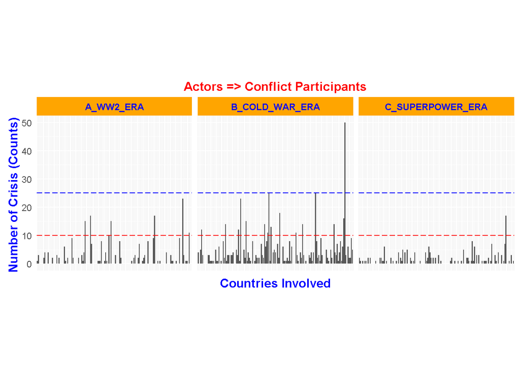

- **Major Actors** (Countries with the highest crisis counts) Worldwide

| Country | Country | Country | Country |
| --- | --- | --- | --- |
| China | Egypt | France | Germany |
| Greece | India | Iraq | Israel |
| Japan | Libya | Pakistan | Russia |
| Syria | Turkey | UK | USA |
| Yugoslavia |  |  |  |

**ANALYSIS**:

- CAVEAT: These next two graphs obscure a good bit of the data on the X axis, that is OK because the key takeaways are simply observing the simple macro trends that are discussed below.
- The key observation from this graph is that the “frequency” of crises and actors increases significantly during the cold war period, and then sharply subsides during the superpower period. There is significant instances of crises during WW2 (which is expected) but the increase during the Cold war period is notable, as in the steep decline in the following era.
- There is an **outlier phenomenon* (a legitimate one) in the cold war era which will continue to manifest itself through out this exploration and should be noted. That outlier is the influence of** “Non-State Actors”** (eg: terrorist groups) and **“Multi-State Actors”** (alliances of nations) in the crisis activities. Since they are not specific sovereign states, they are coded as such, and their presence tends to overshadow the activities of the other single state actors.
- NOTE: For highlighting purposes, observe the rise and fall of crisis frequency between the red and blue lines in the graphs.

### 4.3.2 Crisis Belligerents (Trigents)

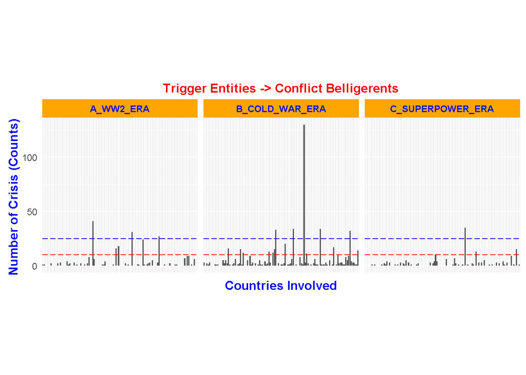

- **Major Trigger Actors** (Belligerents with the highest crisis counts) Worldwide

| Country | Country | Country | Country |
| --- | --- | --- | --- |
| China | France | Germany | India |
| Iran | Iraq | Israel | Italy |
| Japan | Libya | North Korea | Russia |
| South Sudan | Turkey | UK | USA |
| Yugoslavia |  |  |  |

### 4.3.3 Trigger of the Crisis

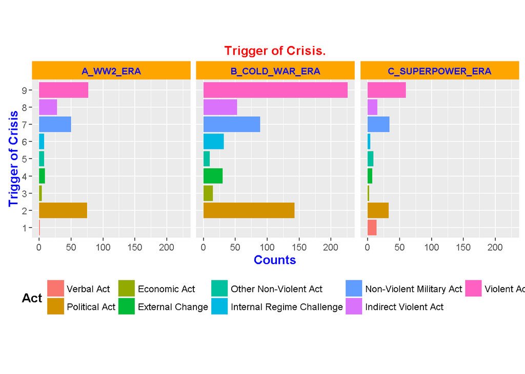

**ANALYSIS**:

- Violent acts and political acts continue to dominate in roughly the same frequency proportions in each key era, except that their (as well as all of the others) frequency during the cold war is greatly pronounced.
- Notice that in the superpower era, overall trigger activity reduces significantly (perhaps due to advanced military and nuclear arms proliferation).

### 4.3.4 Issue of the crisis

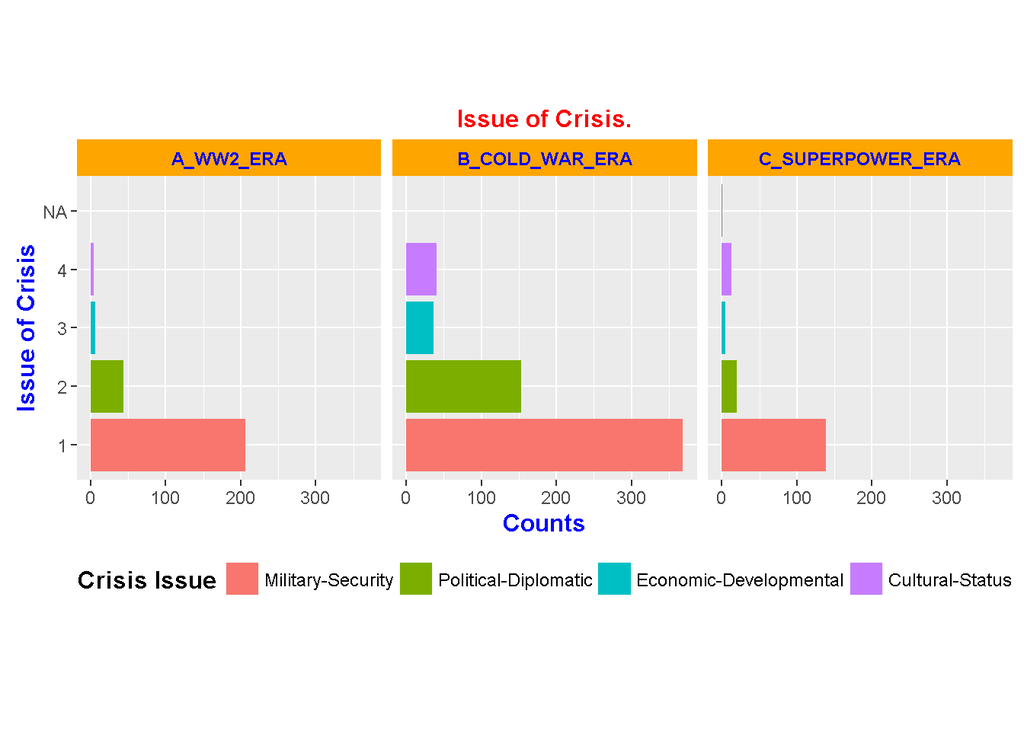

**ANALYSIS**:

- The dominant crisis issue across the eras is military-security followed by political-diplomatic. The same trend of a sharp increase during the cold war era is evident along with the subsequent sharp decline in the super power era.

### 4.3.5 Crisis Management I: Major Response to Crisis Trigger

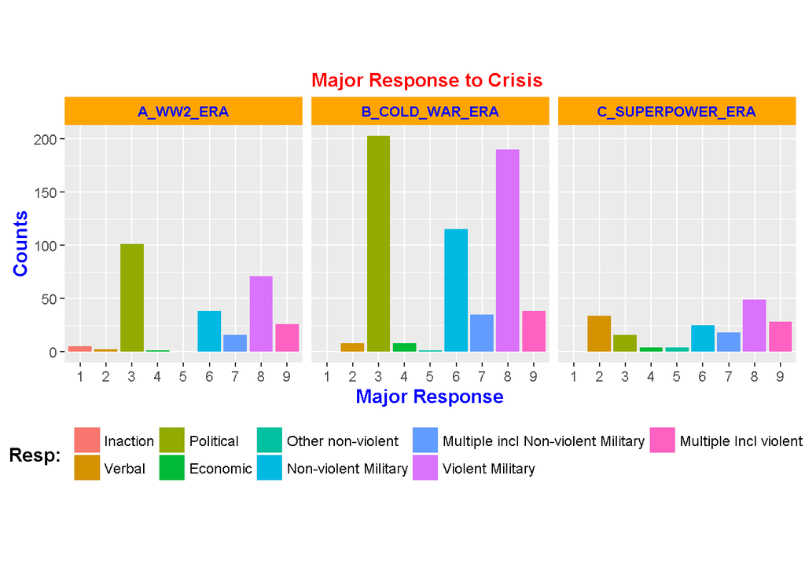

### 4.3.6 Crisis Management II: Principal Coping Technique

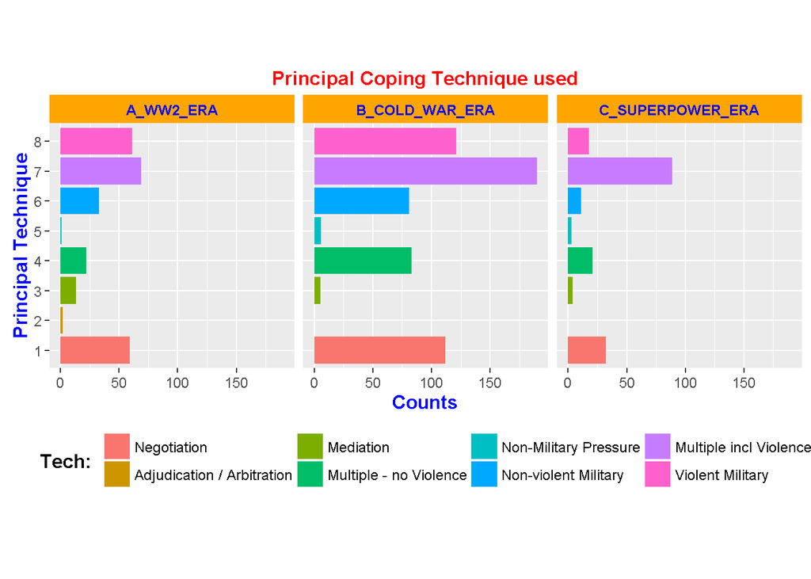

**ANALYSIS**:

- Not surprisingly, the combination of violence and negotiation (in it’s many forms) dominate principle coping techniques during all eras (as well as all of written history). Again, the frequencies of the instances are significantly higher in the cord war era, which is expected considering the history of the time period.
- It should be noted that non-violent techniques also increased during the cold war indicating that in the mix of events, there were some cooler heads prevailing. The would make good sense, given the advancement and proliferation of weapons of mass distruction.

### 4.3.7 Crisis Outcome (Win, Lose, Draw)

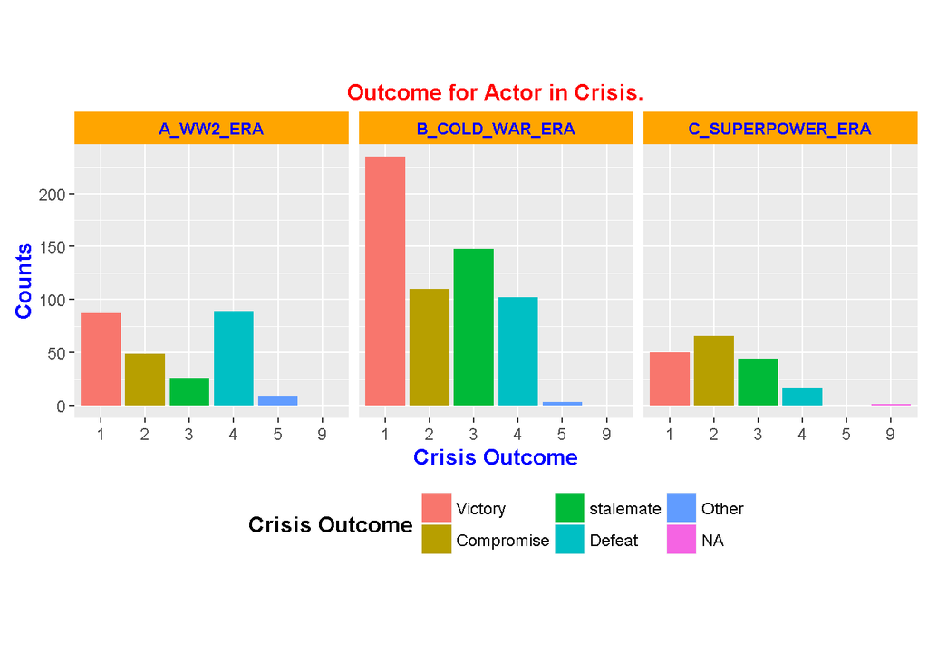

**ANALYSIS**:

- In the WW2 era, outcomes of victory or defeat dominate all other categories with compromise emerging as a distant third option.
- In the Cold war era, this mix changes significantly with victories dominating the frequency chart. It is interesting to note that Stalemates rises significantly in this era along with compromises and defeats. I’d argue that this is also a function of the power struggles of that period between the US-USSR, the advancement of WMD’s, and jockying for geopolitical / economic dominance.
- In the superpower era, the levels return to nearly of the WW2 era, but with a unique phenomenon of compromise surpassing all of the others for the first time. Again, it could be argued that because of the gravity of nuclear weapons, compromise is a much preferred alternative to the gravity of the other outcomes.

### 4.3.8 Power Status of Actor

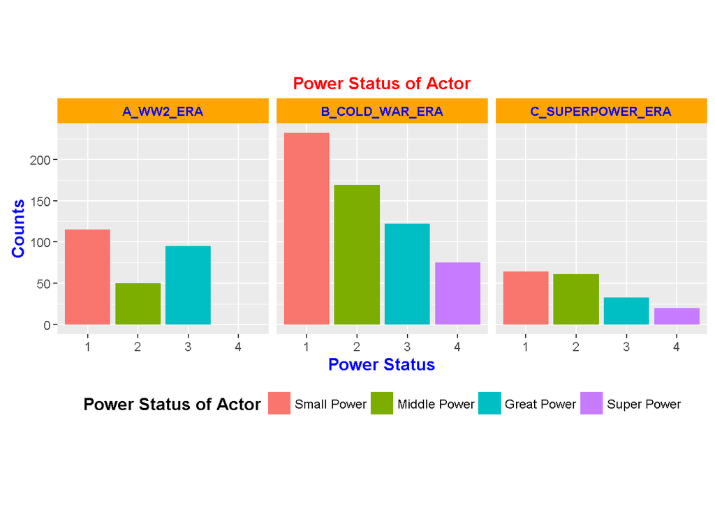

**ANALYSIS**:

- The distribution of Actor power status makes sense given the eras in consideration, and that changes accordingly over time. In the WW2 era, there were a lot of small and great powers with a few middle powers emerging. After WW2, in the cold war era, that mix changed significantly both in gross numbers of small and middle powers and the increase of great powers, plus the emergence of super powers for the first time in history. Those same proportions continue in the superpower era but the frequency is greatly reduced, which is notable given the backdrop of history in that period.

### 4.3.9 Power Status of Threat

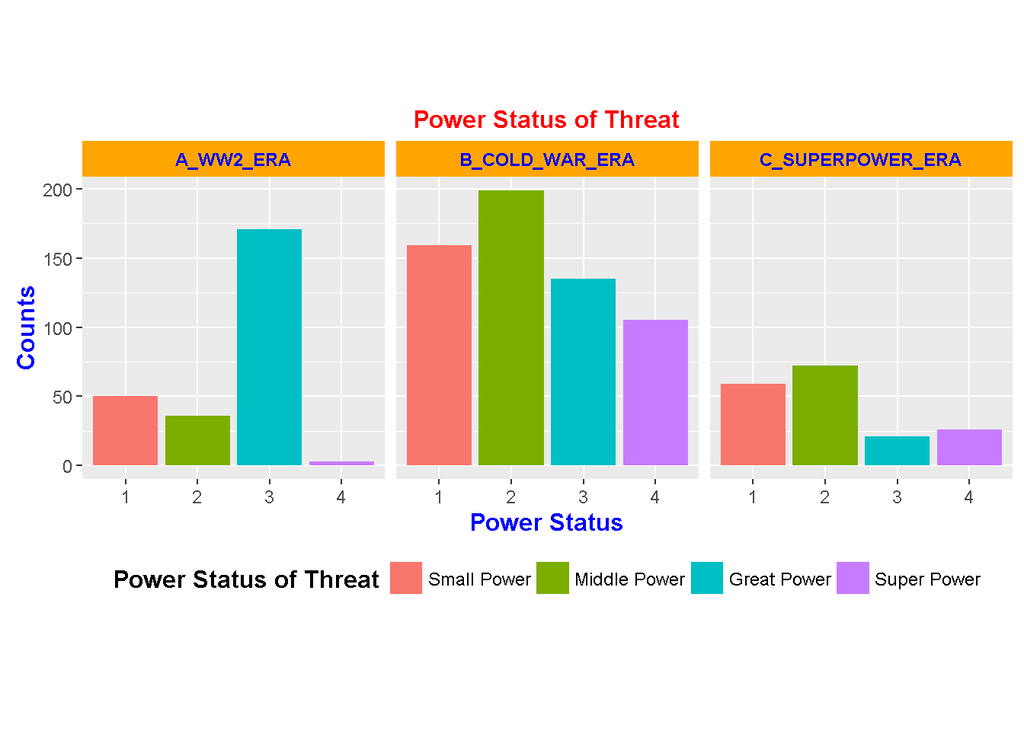

**ANALYSIS**:

- The power status of threats during the WW2 era is what one would expect, dominated by great powers with an introduction of superpowers (at the end of the war).
- The cold war era is different, the power status of the threats are dominated by small and middle powers with the great and super powers also rising in frequency, but less than the small and middle powers.
- By the time the superpower era takes hold the overall frequency is reduced substantially, but of that, small and medium threat powers still dominate in frequency. I wonder if the nuclear stalemate among the maturing of superpowers has made the relevancy of conventional weapons and localized conflicts significant again?

### 4.3.10 Violence experiences by Crisis Actor

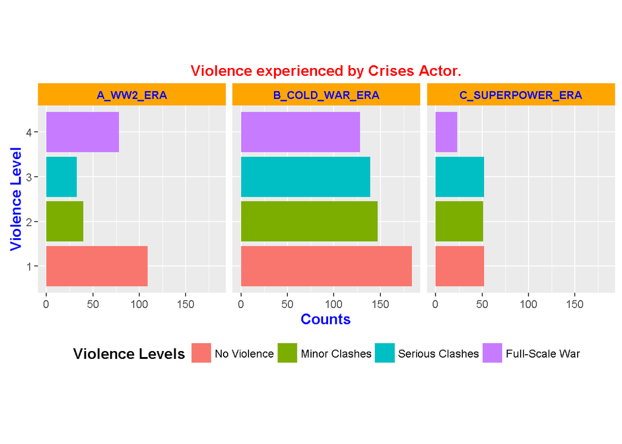

**ANALYSIS**:

- One trend that is notable is that in the WW2 and cold war eras, non-violence levels were higher than all others significantly. That does “not” continue in the superpower era, where there is equal frequencies of non-violence as other forms of violence. This is not a particularly encouraging macro trend to observe, even though the overall levels are lower in the superpower era than the cold war, one would hope to see non-violence levels higher than the others.

### 4.3.11 Political Regime of Crises Actor.

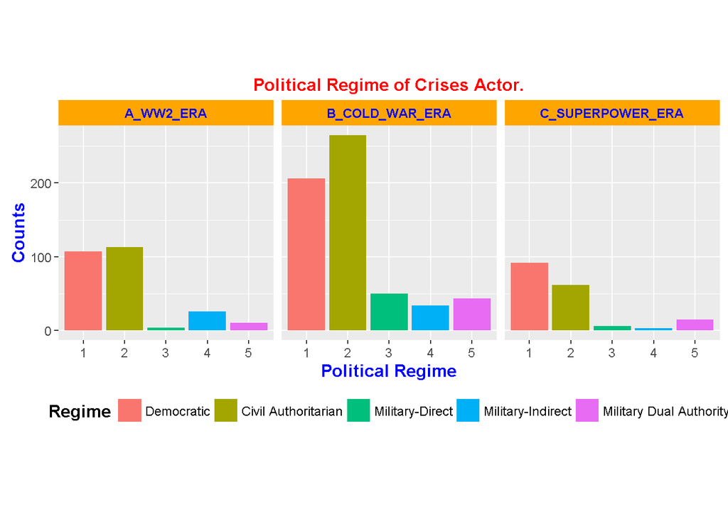

**ANALYSIS**:

- I find this particular analysis interesting in that democracies along with civil authoritarian regimes are most often embroiled with interstate crises as opposed to some form of a military government. That trend goes counter to the conventional narrative about democracies and civil authoritarian regimes, although historically it has definitely been the case that democracies and civil authorities are more prone to get involved in conflicts and then stay involved until the very end.

### 4.3.12 Gravest threat during crisis.

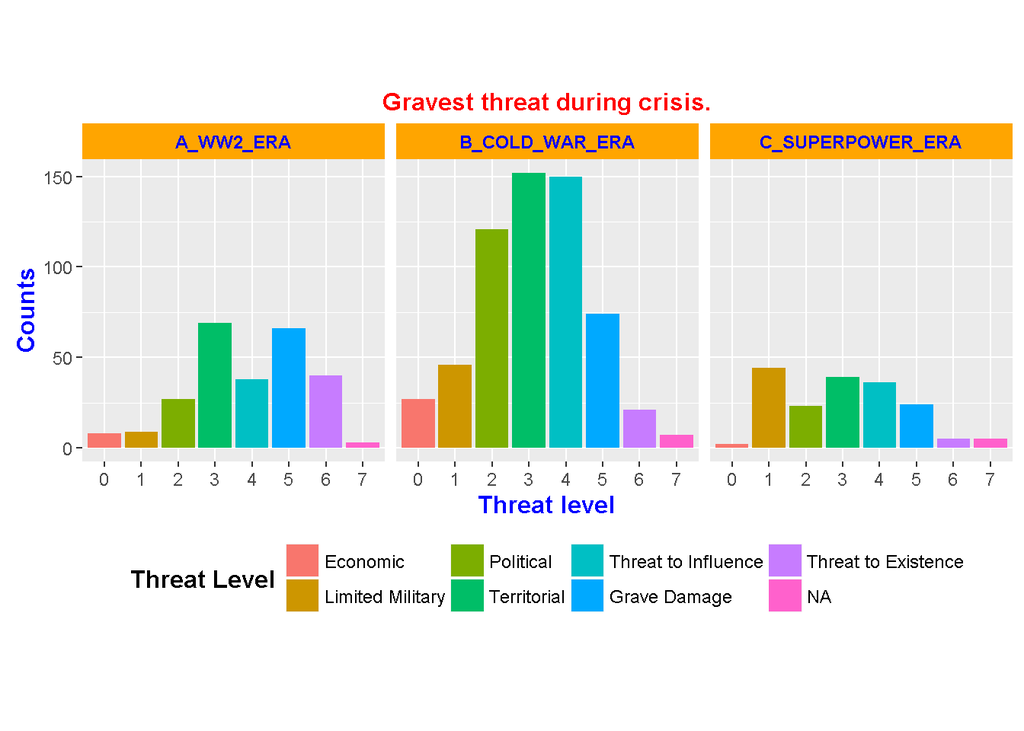

### 4.3.13 Nuclear capability of Crisis Actor

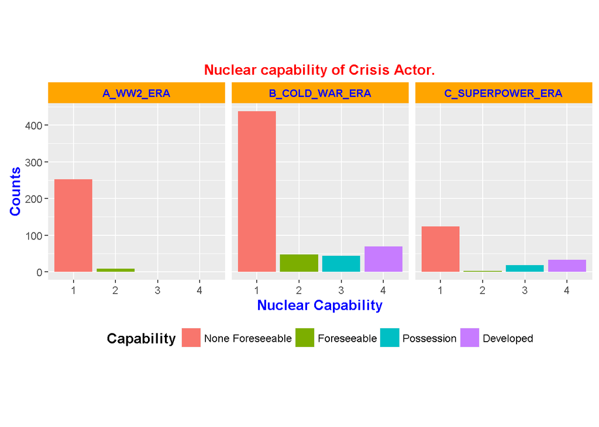

**ANALYSIS**:

- There are a few interesting aspects to exploring the nuclear capabilities across the three eras in question. The first being that in the cold war era there were a decent number of “foreseeable” actors who “might” develop nuclear weapons sometime in the future sometime. By the time the superpower era dawns, that figure is drastically reduced, which is understandable given the gravity of consequences given the enhanced distructive power of nuclear weapons.
- The next (also understandable for the same reasons) is that the number of actors in “posession” of nuclear weapons has also drastically reduced.
- Also note in the WW2 era, it was observed that some actors “could” develop nuclear weapons. Hindsight in this case is very interesting.

### 4.3.14 Alliance Patterns

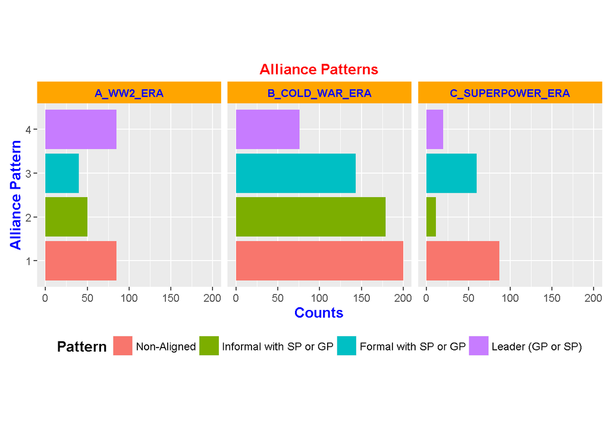

**ANALYSIS**:

- The latent dominant trend across all eras is for a high frequency of non-alligned (or neutral) parties. The alliance leaders have shrunk (to just a few) proportionally, but have kept those who are formally alligned with them (as historical treaties like NATO) would suggest.
- One of the more interesting developments is that the informal (or loose) alliances have significantly reduced in the superpower era. I wonder if that is a function of the necessity of the informal alliances has dropped off, or their usefulness has.

# 5 Explorations of Actors (Participants)

This section explores the set of world actors who have the **highest crisis frequences** (as shown by the **size of the pink circles** on the map below.) by examining a similar set of attributes as the previous section.

## 5.1 Major Crisis Actors World Wide

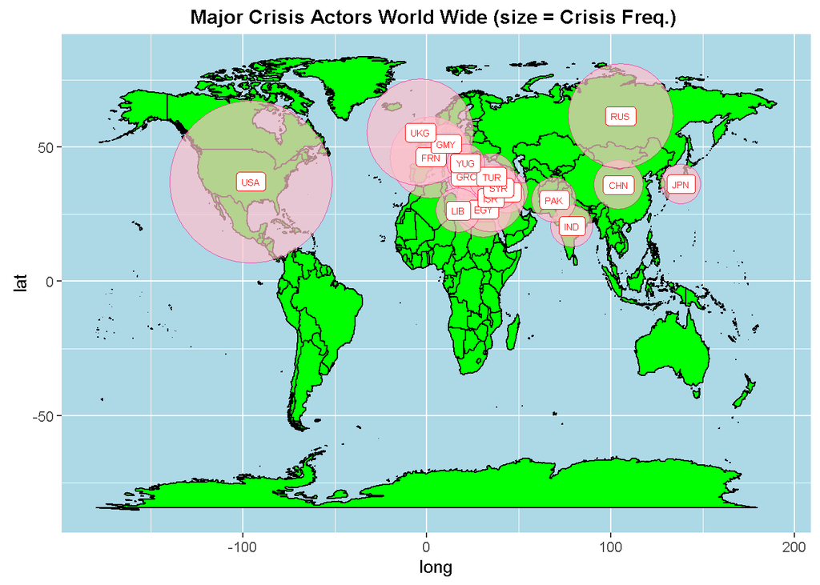

## 5.2 Major Actors (those with the highest crisis counts) Worldwide

1. “China”
2. “Egypt”
3. “France”
4. “Germany”
5. “Greece”
6. “India”
7. “Iraq
8. “Israel
9. “Japan”
10. “Libya”
11. “Pakistan
12. “Russia
13. “Syria”"
14. “Turkey”
15. “United Kingdom”
16. “USA”
17. “Serbia”

## 5.3 Exploration of Major Actors World Wide by ERA (WW2, Cold War, Super Power)

### 5.3.1 Actors and Trigger Acts of Crisis

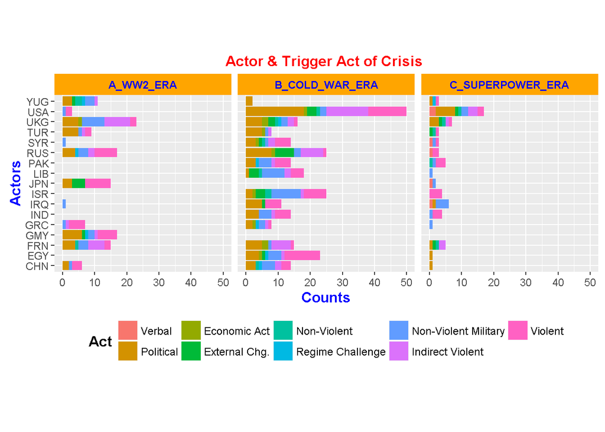

**ANALYSIS**:

- The trigger acts in the WW2 era are as expected, high frequency in the case of the UK, Germany, France, Japan, and Russia, while low for the US (a late entrant into the conflict).
- The cold war in contrast, sees the US frequency skyrocketing dominated by poltiical, and violent (direct and indirect) acts. Russia, Israel and Egypt also have nearly identical levels of trigger acts with a mix of acts.
- The superpower era sees all of those levels recede drastically across the board with the notables being Israel (which experiences exclusively violent trigger acts), and the USA (which still leads in trigger act frequencies with a relatively equal representation of trigger acts across the board).

### 5.3.2 Crisis Issue

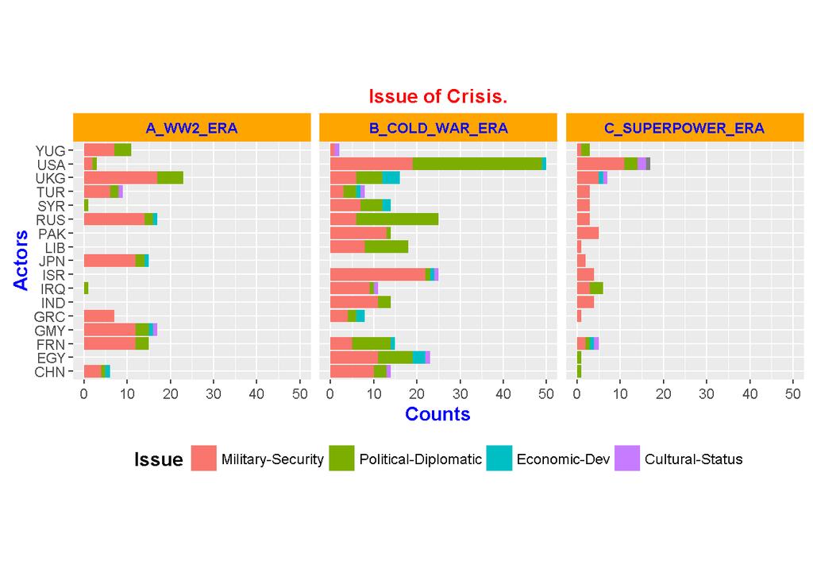

**ANALYSIS**:

### 5.3.3 Power Status: Actor

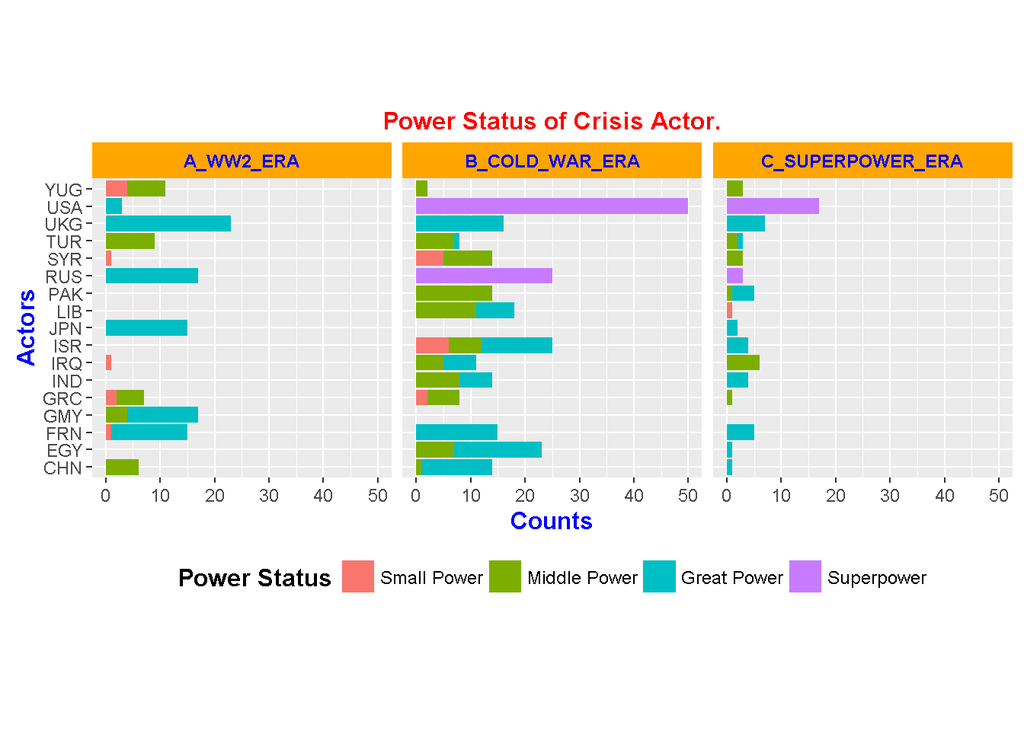

**ANALYSIS**:

- During the WW2 era there were 6 great powers and no super powers, with the UK, Russia, Japan, Germany, and France comprising the strongest great powers and the USA the weakest of the six.
- In the wake of that conflict into the cold war, the US and Russia emerge as the lone pair of superpowers with the US far ahead in the power factor than any of the others.
- Fast forward to the superpower era and we still see the US as the lone military superpower with Russia greatly weakened but still considered a superpower.
- Again, the same patterns of heightened frequency during the cold war with a steep decline across the board into the superpower era is observed.

### 5.3.4 Power Status: Threat

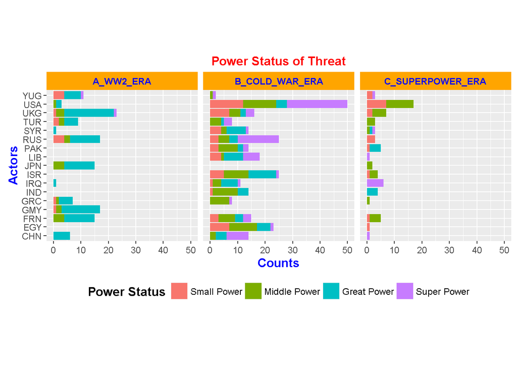

**ANALYSIS**:

### 5.3.5 Gravest Threat

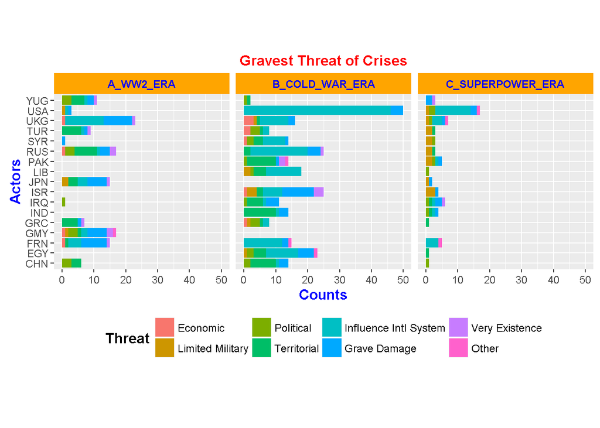

**ANALYSIS**:

### 5.3.6 Major Response

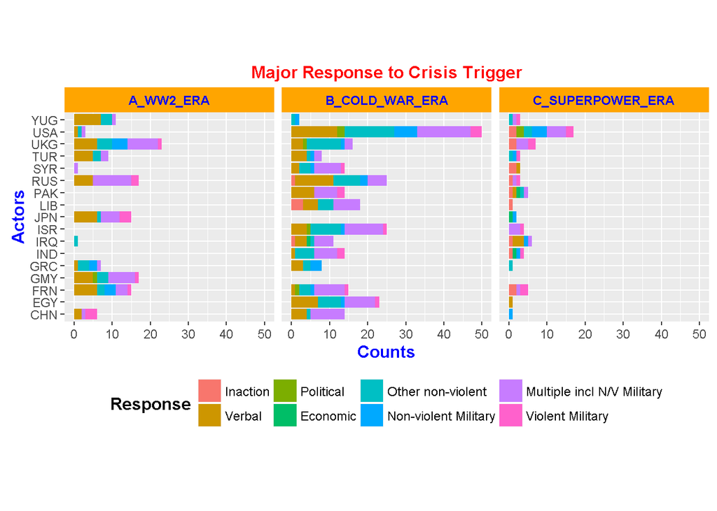

**ANALYSIS**:

- Interesting trends consistent in both the WW2 and Cold War eras is the presence of “Verbal” and “non-violent military” responses to the trigger acts of the belligerents. In the cold war, the incidences of non-violent responses of all sorts grew in frequency across the board whereas in the superpower era there was more instances of inaction and non-violent responses which suggest a decent measure of calmer heads when faced with interstate challenges.

### 5.3.7 Principal Technique

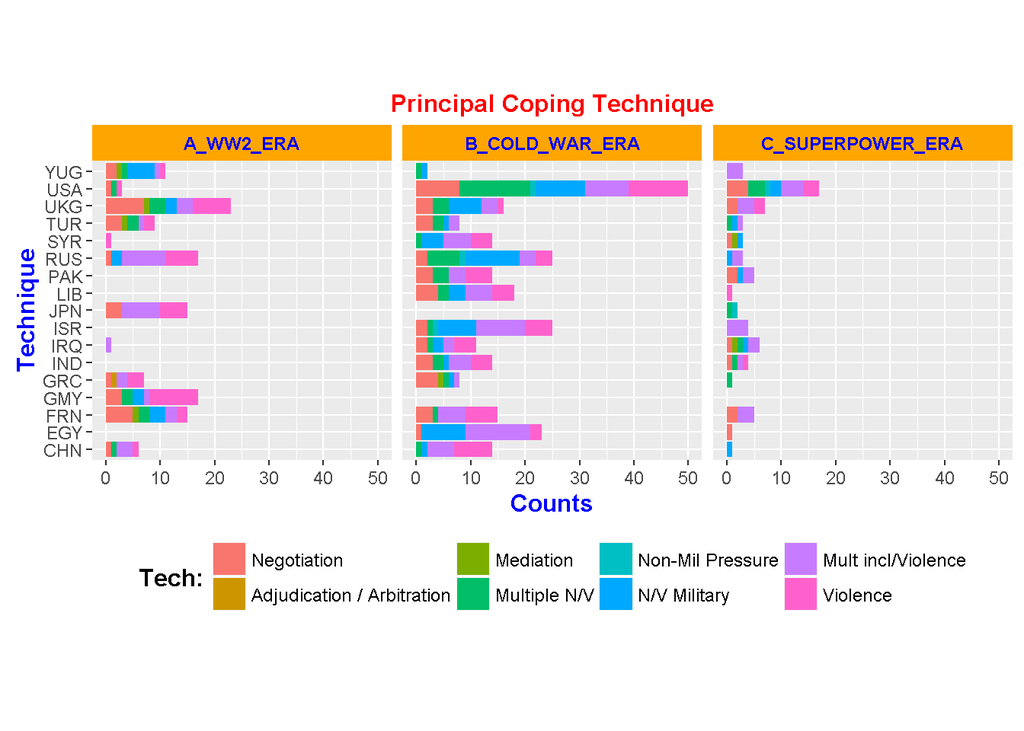

**ANALYSIS**:

- WW2 witnessed violence as the principle coping technique across the spectrum of key players with negotiation seeing some frequency.
- In the cold war however, there were a lot more diplomatic pressures used as a coping technique, but were offset by the amount of violence also incorporated into the era.
- The superpower era saw a lot less “”direct" violence, and more “multiple” including violence techniques which would make sense given the hsitorical amount of intel and covert ops used by the superpowers during that era.

### 5.3.8 Violence Levels

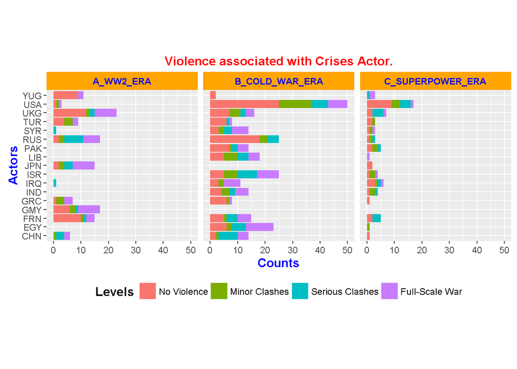

**ANALYSIS**:

- The WW2 era witness it’s fair share of full scale war, but it also saw a lot of non-violence as well by the major players of that time period. The Cold War encompassed more frequency of non-violence, minor clashes, with just a few serious clashes and some bouts of full scale war. Interestingly (or predictably), the superpower era saw a dramatic reduction in counts across the board with all players, with only a few instances of serious clashes and full scale war.

### 5.3.9 Political Regime

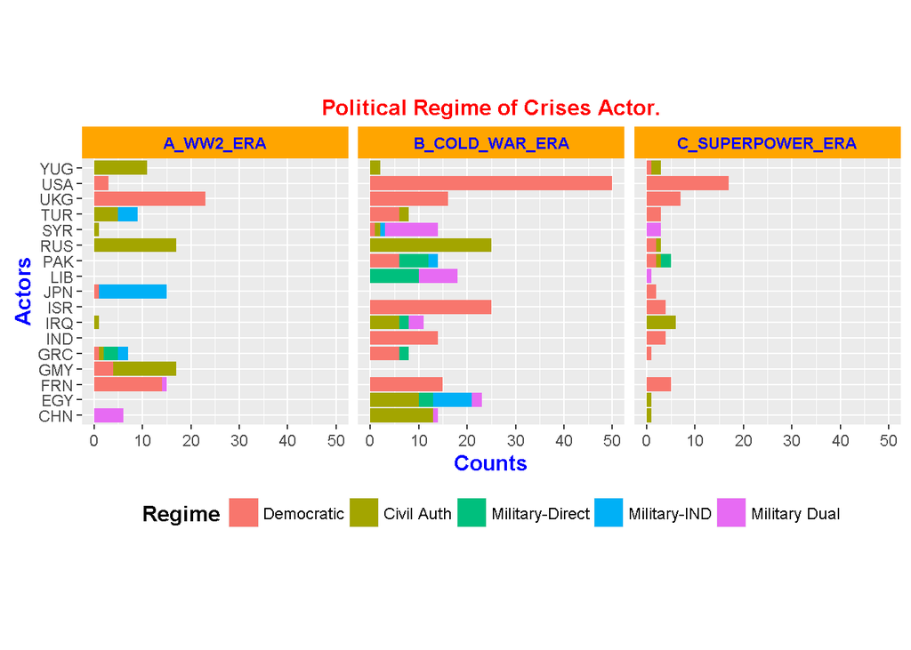

**ANALYSIS**:

- The single most obvious trend among the major players is for democracies and civil authorities to be embroiled in interstate crises more than any other political regime in existance, far more than any type of military shared government. This might be because the majority of the major entities were either democratic or civil authortarian with only a few military type governments available, but that trend spans three eras as well.
- As an acid test I ran the plot again on the “entire” dataset (not shown), and that general trend held up fairly well. It has been suggested by many historians that democracies and civil authorities are **not** good international neighbors precisely because they tend to be frequently involved in interstate crises (and protracted conflicts), and tend to see them through until the very end.

### 5.3.10 Nuclear Capability

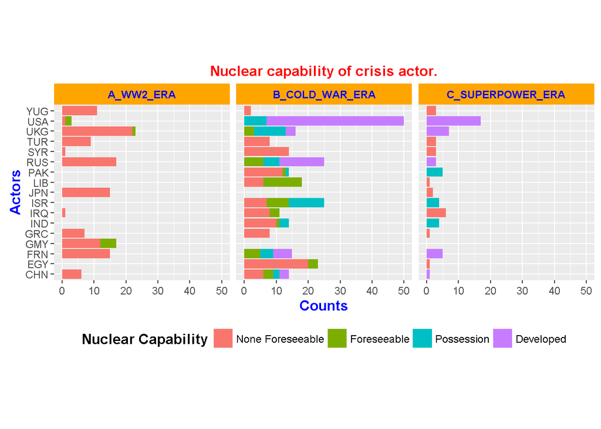

**ANALYSIS**:

- The general trends concerning nuclear capabilities between eras continues with none existing during WW2, then in the Cold War the US, Russia, UK, Pakistan, Israel, India, France and China all come into posession of such WMDs. The US, UK, France, Russia, and China have all developed their own nuclear programs with Pakistan, Israel and India posessing nuclear weapons but not having developed them. The real concern at this point in history is the number of states who “might” be able to develop them in the future.
- In the superpower era, we see the former developed and posession states continue their status, but with those who “might” develop them no longer having the capability to produce them. This is probably a function of the international non-proliferation treaties being enforced.

### 5.3.11 Alliance Patterns

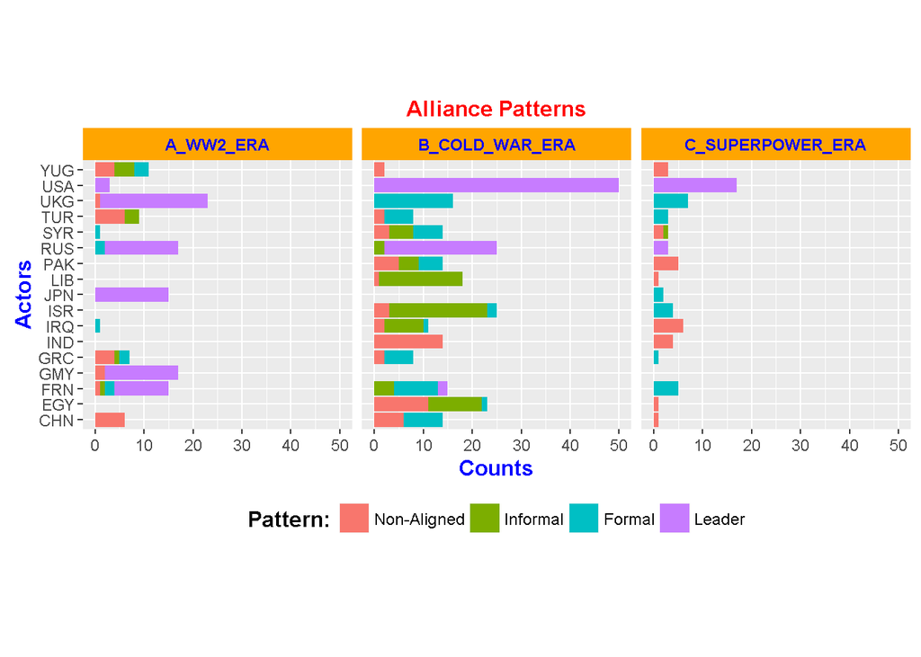

**ANALYSIS**:

### 5.3.12 Crisis Outcome

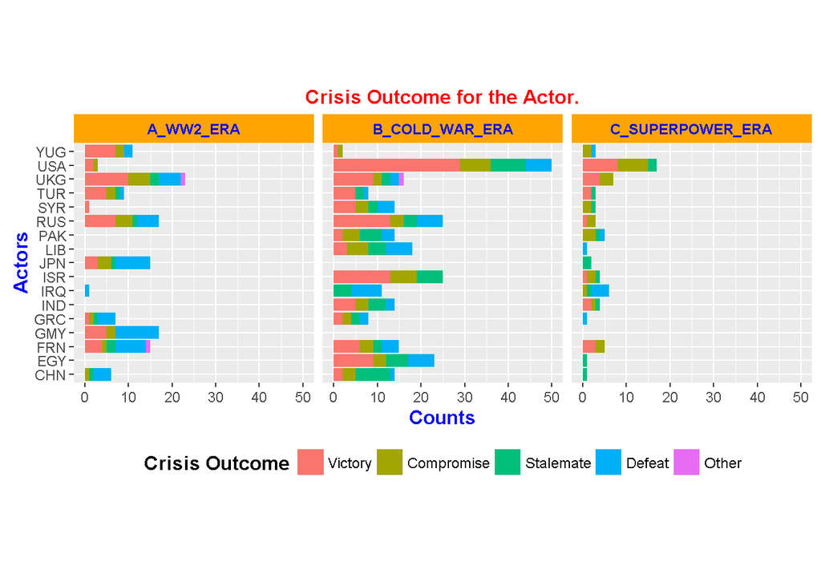

**ANALYSIS**:

# 6 Exlporations of USA crises during the Cold War ERA

- The USA is a unique case in the Cold War ERA and warrants a closer inspection of it’s behavior relative to the trigger actors (belligerents) of that period, particularly considering the backdrop of various technological advances, economic progress, globalization, and other key influential trends of that era.

## 6.1 USA Cold War Crisis Map

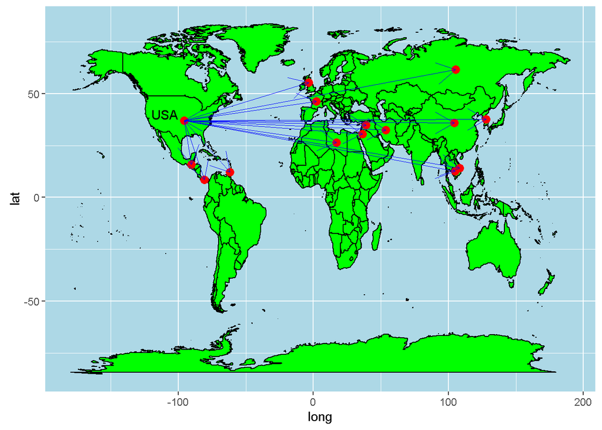

**ANALYSIS**:

- For the purposes of this particular exploration, it is beneficial to peruse the list of USA adversaries, the corresponding crisis, and its outcome below:

### 6.1.1 USA Cold War Crisis List: (Adversary, Crisis, Outcome)

```
## Cambodia
##   crisname Crisis_Result
## 1 MAYAGUEZ       Victory
##
## China
##           crisname Crisis_Result
## 1    KOREAN WAR II    Compromise
## 2  TAIWAN STRAIT I     stalemate
## 3 TAIWAN STRAIT II       Victory
##
## Cuba
##      crisname Crisis_Result
## 1 BAY OF PIGS        Defeat
##
## Vietnam
##               crisname Crisis_Result
## 1       GULF OF TONKIN     stalemate
## 2  VIETNAM SPRING OFF.       Victory
## 3 INVASION OF CAMBODIA     stalemate
## 4 VIETNAM PORTS MINING    Compromise
## 5    CHRISTMAS BOMBING    Compromise
##
## France
##        crisname Crisis_Result
## 1 DIEN BIEN PHU        Defeat
##
## Grenada
##              crisname Crisis_Result
## 1 INVASION OF GRENADA       Victory
##
## Guatemala
##    crisname Crisis_Result
## 1 GUATEMALA       Victory
##
## Iran
##              crisname Crisis_Result
## 1 US HOSTAGES IN IRAN    Compromise
## 2     IRAN NUCLEAR II    Compromise
##
## Iraq
```

[output cut: 65 more lines]

```
## 7        CUBAN MISSILES       Victory
## 8           SIX DAY WAR       Victory
## 9  CIENFUEGOS SUB. BASE       Victory
## 10 AFGHANISTAN INVASION     stalemate
## 11    NICARAGUA MIG-21S     stalemate
##
## Syria
##                 crisname Crisis_Result
## 1  SYRIA/TURKEY CONFRNT.       Victory
## 2 SYRIA CHEMICAL WEAPONS    Compromise
##
## United Kingdom
##          crisname Crisis_Result
## 1 TRUMAN DOCTRINE       Victory
##
```